# Ramada by Wyndham Hamilton City Center: Review Benchmarking and Price Prediction

# 7. Sentiment analysis for n = 1 to 6

Sentiment analysis measures whether text is positive or negative. We score every n-gram with the **Bing dictionary**, which labels words as positive or negative:

- Score = (number of positive words) - (number of negative words) in the n-gram.
- **Negation:** if the word *before* a sentiment word is a negator (“not”, “no”, “never”, “wasn’t”, “didn’t” and so on), we flip its sign. “Clean” is positive, but “not clean” is negative. For single words (n = 1) negation cannot be detected, because there is no previous word in the window. Longer windows catch more negations.
- An n-gram scoring below 0 is **negative**, above 0 **positive** and exactly 0 **neutral**.

We repeat this for **n = 1 to 6** for Ramada and for the Hamilton competitors, so we can see how the sentiment results change with n, and whether the conclusions are stable.

Limitation: the negation rule is simple and sometimes wrong (for example “couldn’t lie in bed”), and the dictionary does not know hotel-specific meanings. We therefore check that the scores agree with the star ratings.

```
## Ramada n-grams scored for n = 1 to 6: 32,745 | 32,396 | 32,047 | 31,698 | 31,349 | 31,000
```

| n | ramada_pct_negative | competitor_pct_negative | ratio_negative | avg_score_ramada | avg_score_competitor | p_value | rho_with_stars | pct_changed_by_negation |
| --- | --- | --- | --- | --- | --- | --- | --- | --- |
| 1 | 3.11 | 2.02 | 1.54 | 0.05 | 0.08 | <2e-16 | 0.75 | 0 |
| 2 | 5.99 | 3.88 | 1.54 | 0.09 | 0.16 | <2e-16 | 0.77 | 0.49 |
| 3 | 8.52 | 5.53 | 1.54 | 0.13 | 0.24 | <2e-16 | 0.77 | 0.96 |
| 4 | 10.8 | 7 | 1.54 | 0.16 | 0.31 | <2e-16 | 0.77 | 1.42 |
| 5 | 12.9 | 8.29 | 1.55 | 0.2 | 0.39 | <2e-16 | 0.77 | 1.87 |
| 6 | 14.6 | 9.41 | 1.56 | 0.24 | 0.47 | <2e-16 | 0.77 | 2.3 |

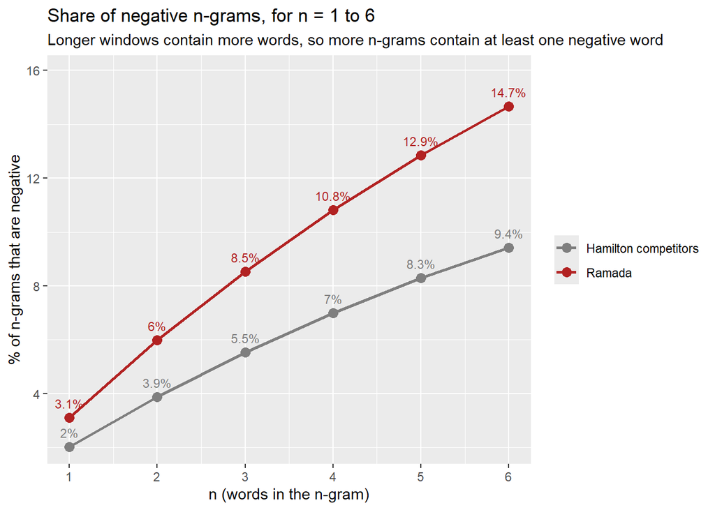

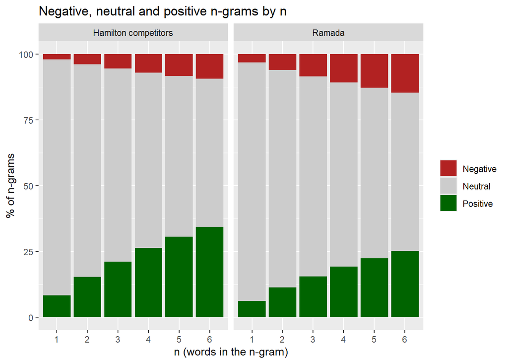

For each review we average the score of its n-grams and compare with the stars the guest gave.

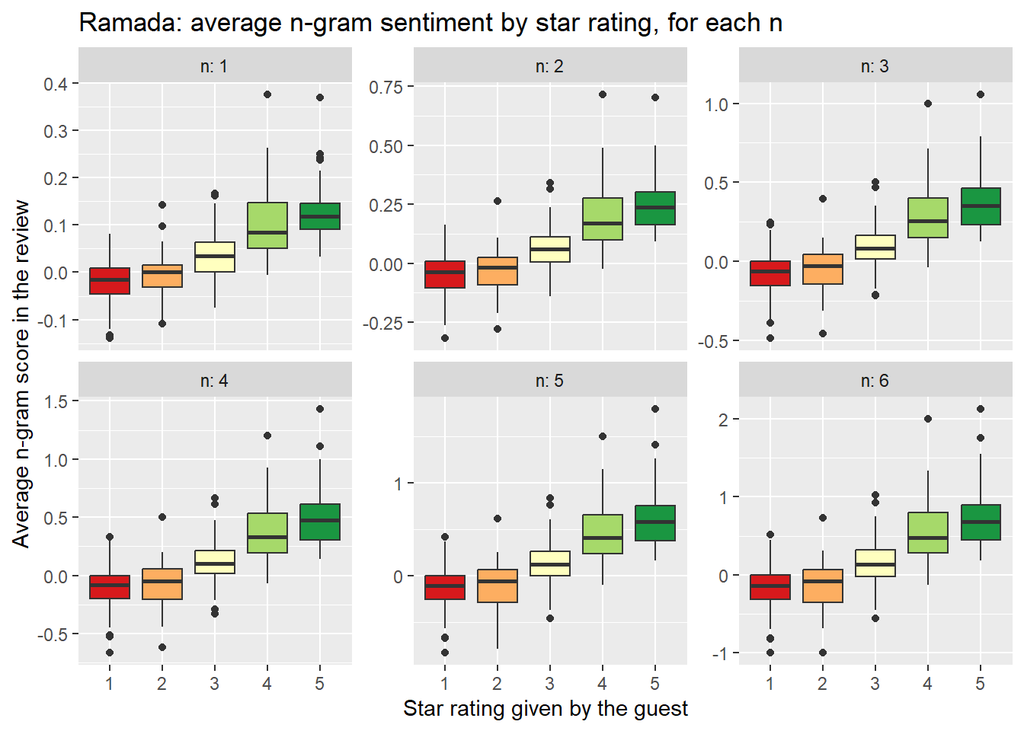

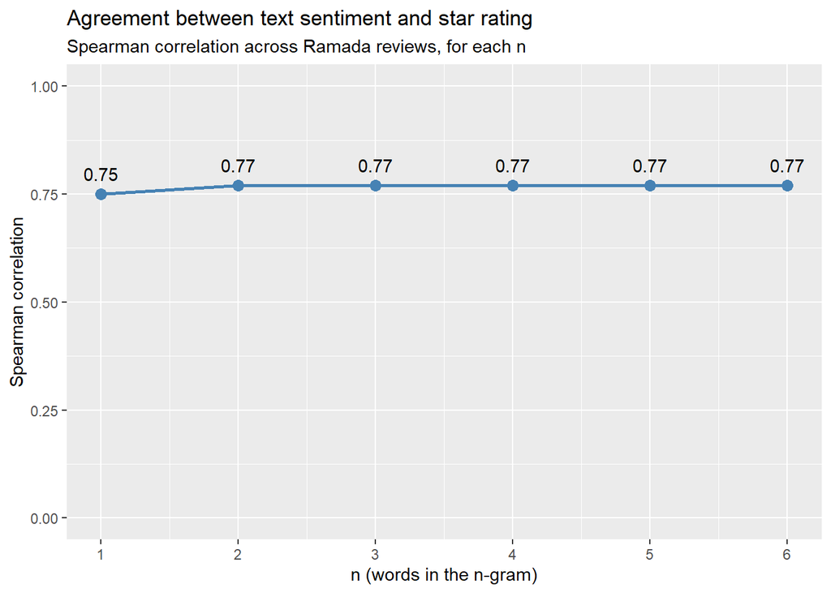

Examples of 6-grams whose score changed once negators were considered:

| ngram | score_without_negation | score_with_negation |
| --- | --- | --- |
| wasn't warm also noticed the lights | 1 | -1 |
| if service has not improved some | 1 | -1 |
| expect tv not work or get | 1 | -1 |
| but wouldn't recommend staying in the | 1 | -1 |
| not helped by the fact the | 1 | -1 |
| managers attention maintenance was not great | 1 | -1 |
| no problems getting sorted i was | -1 | 1 |
| a good stay no complaints clean | 1 | 3 |

**Trend over time (4-grams, a middle value of n):**

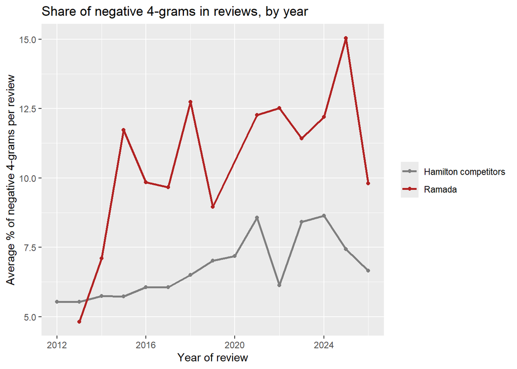

**The strongest negative and positive phrases (n = 2, 4 and 6).** Because n-grams overlap, one sentence creates several nearly identical n-grams, so we keep only the single strongest n-gram from each review.

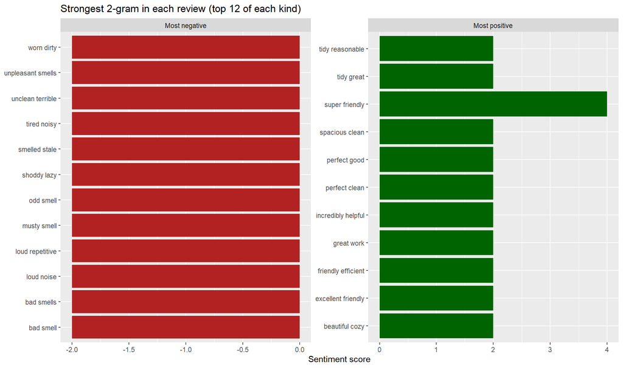

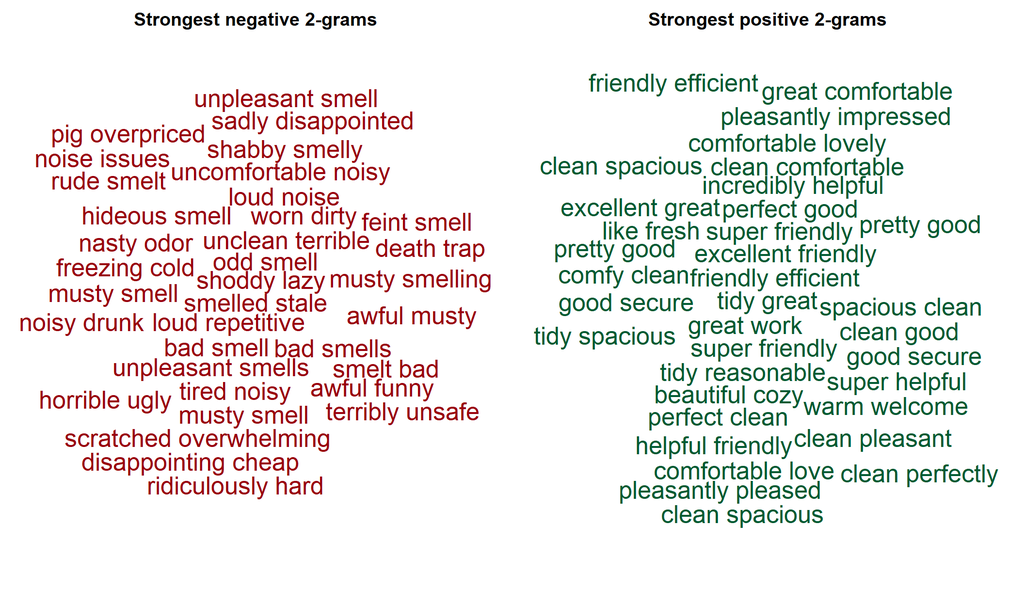

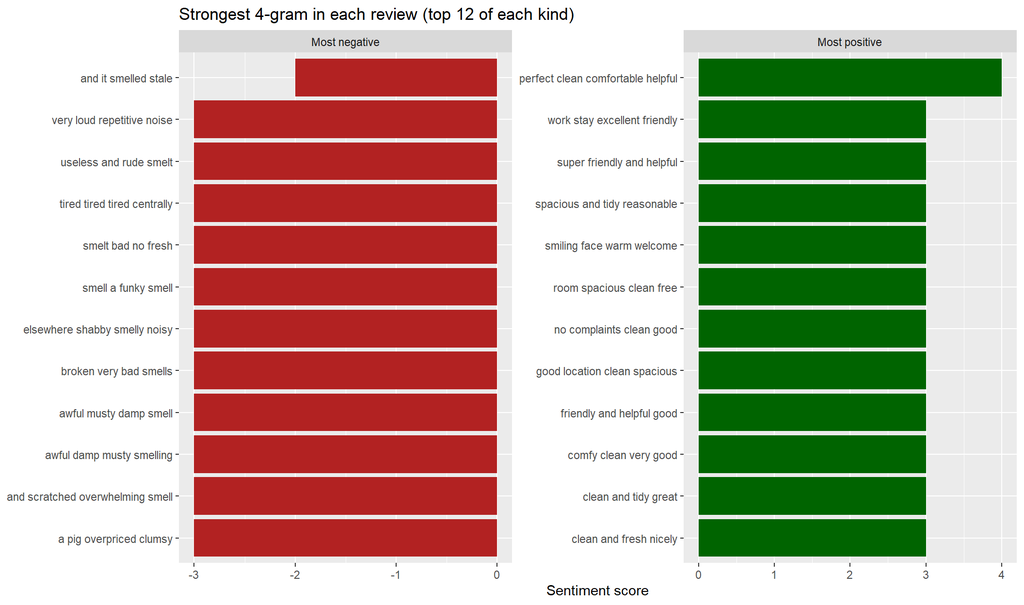

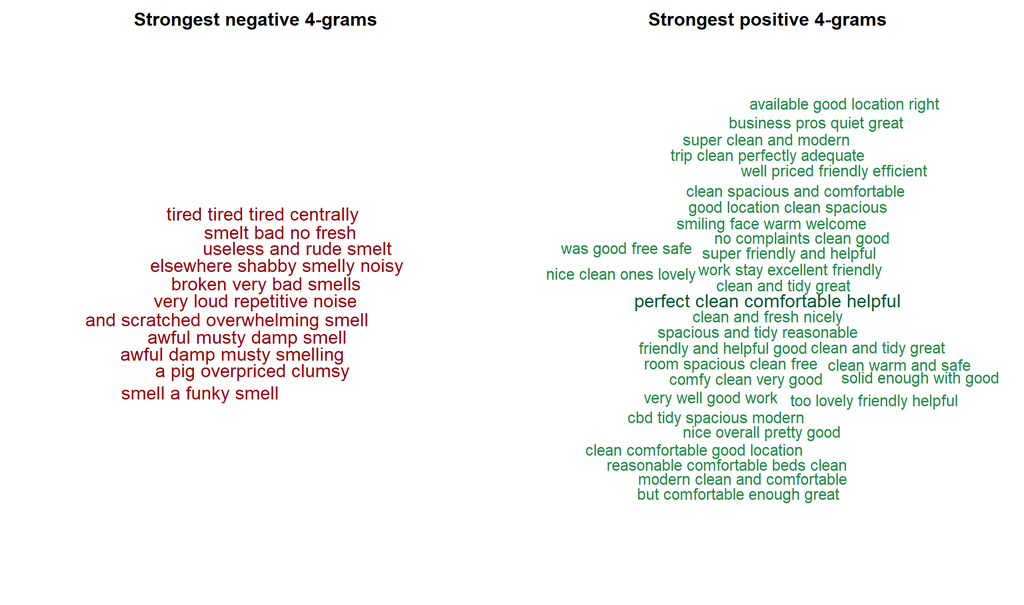

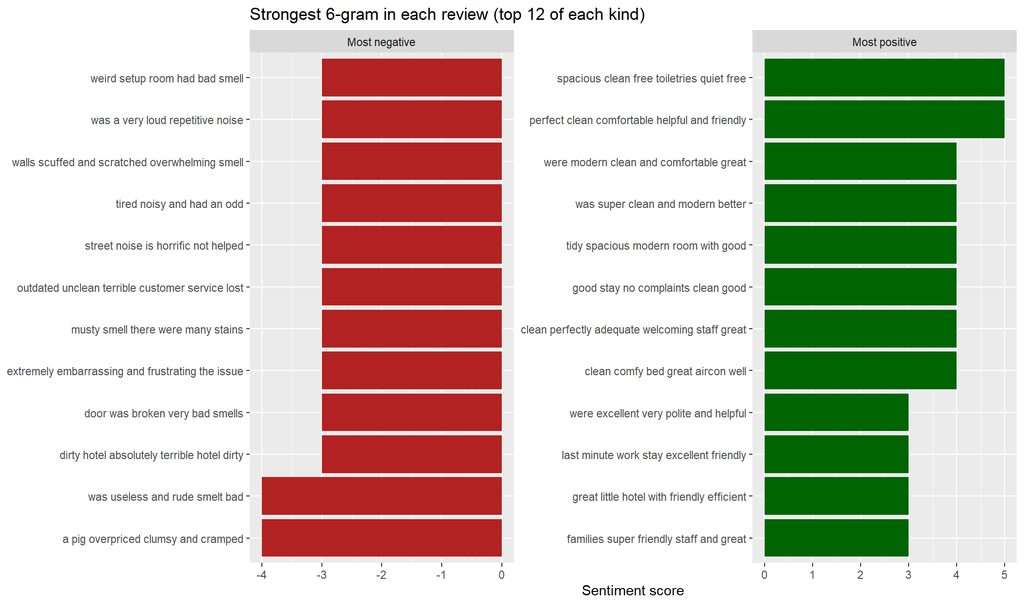

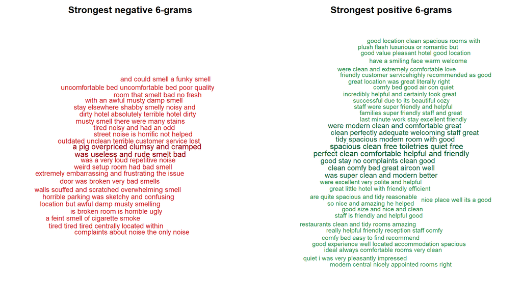

**Interpretation:**

At every n from 1 to 6, Ramada has about 1.5 times (1.54 to 1.56) the share of negative n-grams of the competitors (for example 14.6% vs 9.4% at n = 6, and 3.1% vs 2.0% at n = 1).

Ramada’s average score is roughly half the competitors’ at each n, and the Wilcoxon test gives p < 0.001 every time. The finding is robust.

A longer window contains more words, so it is more likely to contain at least one negative (or positive) word. This is why the share of negative n-grams grows from about 3% to about 15%. Compare Ramada and competitors at the same n, never across different values of n.

The correlation between a review’s average n-gram score and its stars is 0.75 for single words and 0.77 for every n from 2 to 6. The boxplots rise steadily from 1 to 5 stars for every n. So n-grams (which can capture some negation) are slightly better than single words, but there is no gain beyond n = 2.

**extra charges**: the repeated phrases extra cost (6 reviews, average 2.3), pay for park and pay for wifi (both rated about 1.5 to 2.7).

## 7.1 Which aspects do guests talk about? (Aspect analysis)

**Why are we doing this?** To turn text into clear business topics, we search each review for keywords linked to an aspect (for example “noise”, “loud” for *Noise & sleep*). For every aspect we compute how often guests mention it and what overall rating those reviews give, for Ramada and for competitors. If Ramada’s reviews that mention an aspect are much lower than the competitors’ reviews on the same aspect, that aspect is a **weakness**.

| aspect | Ramada_pct_mention | Comp_pct_mention | Ramada_rating | Comp_rating | gap |
| --- | --- | --- | --- | --- | --- |
| Room & bed | 86 | 83.5 | 2.93 | 3.88 | -0.95 |
| Cleanliness | 52.4 | 52.8 | 2.94 | 3.9 | -0.96 |
| Noise & sleep | 30.7 | 27.8 | 2.61 | 3.81 | -1.2 |
| Staff & service | 59.9 | 65.6 | 3.22 | 4 | -0.78 |
| Location | 61.3 | 48.8 | 3.38 | 4.12 | -0.74 |
| Parking | 41.8 | 20.8 | 3.08 | 3.92 | -0.84 |
| Value & price | 35 | 30.6 | 3.05 | 3.73 | -0.68 |
| Facilities & breakfast | 30.4 | 49.3 | 2.9 | 4 | -1.1 |

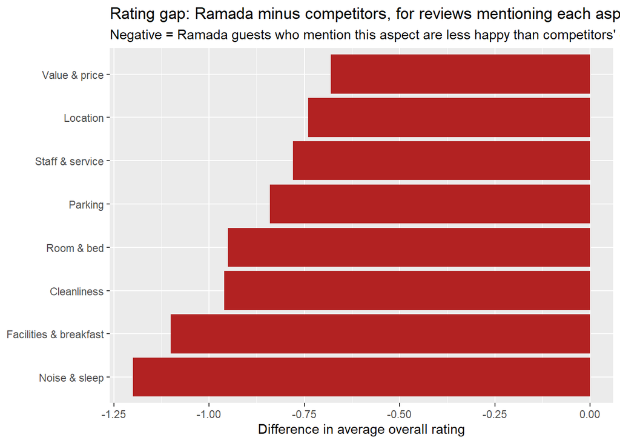

**Interpretation:**

- **What guests talk about:** *Room & bed* (86%), *Staff & service* (60%), *Location* (61%) and *Cleanliness* (52%) are the most discussed topics. Compared with competitors, Ramada guests talk **much more about parking (42% vs 21%)** and location (61% vs 49%), and **much less about facilities and breakfast (30% vs 49%)**, which suggests Ramada offers or promotes fewer facilities.
- **How happy those guests are:** Ramada’s reviews are lower than competitors’ for every aspect. The biggest gaps are **Noise & sleep (-1.2; Ramada average 2.61, the lowest of all aspects)**, **Facilities (-1.1)**, **Cleanliness (-0.96)**, **Room & bed (-0.95)** and **Parking (-0.84)**.
- The smallest gaps are for **Value & price (-0.68)** and **Location (-0.74)**, and the reviews that mention location and staff are Ramada’s happiest ones (average ratings of about 3.4 and 3.2).
- *Caution:* because Ramada’s overall rating is lower, some gap is expected for every aspect. The value of this analysis is in the **ranking**: noise and sleep, facilities, cleanliness and rooms are where the unhappiness is concentrated. A keyword match also does not tell us if the comment was positive or negative.

## 7.2 Logistic regression: what makes a review negative?

Linear regression predicts a *number*. **Logistic regression** predicts a *yes/no outcome*; here, “is this review negative (1 or 2 stars)?”. The model returns **odds ratios**:

- An odds ratio:-
- **above 1** means the factor makes a negative review *more* likely,
- **below 1** means *less* likely,
- **1** means no effect.

We use the aspect keywords from the previous section (does the review mention noise, location, parking and so on?), the type of traveller and the length of the review. This tells us which topics are linked to unhappy guests, while holding the other factors constant.

```
## Share of Ramada reviews that are negative: 37 %
```

```
##
## Call:
## glm(formula = negative ~ m_room + m_clean + m_noise + m_staff +
##     m_location + m_parking + m_value + m_facilities + trip_type +
##     log_words, family = binomial, data = logit_train)
##
## Coefficients:
##                   Estimate Std. Error z value Pr(>|z|)
## (Intercept)       -3.85716    1.05725  -3.648 0.000264 ***
## m_room            -0.39692    0.46591  -0.852 0.394257
## m_clean            0.10200    0.30432   0.335 0.737504
## m_noise            0.52282    0.31680   1.650 0.098879 .
## m_staff           -0.90319    0.31163  -2.898 0.003752 **
## m_location        -1.37762    0.29939  -4.601 4.20e-06 ***
## m_parking         -0.39365    0.31269  -1.259 0.208070
## m_value           -0.27654    0.30321  -0.912 0.361747
## m_facilities       0.10591    0.33427   0.317 0.751372
## trip_typeBusiness  0.05943    0.38185   0.156 0.876324
## trip_typeCouples  -1.21913    0.47545  -2.564 0.010343 *
## trip_typeFamily   -0.88491    0.51388  -1.722 0.085070 .
## trip_typeFriends   0.26033    0.59418   0.438 0.661288
## trip_typeSolo     -0.77374    0.74578  -1.037 0.299508
## log_words          1.25005    0.28856   4.332 1.48e-05 ***
## ---
## Signif. codes:  0 '***' 0.001 '**' 0.01 '*' 0.05 '.' 0.1 ' ' 1
##
## (Dispersion parameter for binomial family taken to be 1)
##
##     Null deviance: 369.44  on 279  degrees of freedom
## Residual deviance: 298.41  on 265  degrees of freedom
## AIC: 328.41
##
## Number of Fisher Scoring iterations: 4
```

| term | odds_ratio | low | high | p_value |
| --- | --- | --- | --- | --- |
| m_room | 0.672 | 0.27 | 1.68 | 0.394 |
| m_clean | 1.11 | 0.61 | 2.01 | 0.738 |
| m_noise | 1.69 | 0.907 | 3.14 | 0.099 |
| m_staff | 0.405 | 0.22 | 0.746 | 0.004 |
| m_location | 0.252 | 0.14 | 0.453 | 0 |
| m_parking | 0.675 | 0.365 | 1.25 | 0.208 |
| m_value | 0.758 | 0.419 | 1.37 | 0.362 |
| m_facilities | 1.11 | 0.577 | 2.14 | 0.751 |
| trip_typeBusiness | 1.06 | 0.502 | 2.24 | 0.876 |
| trip_typeCouples | 0.295 | 0.116 | 0.75 | 0.01 |
| trip_typeFamily | 0.413 | 0.151 | 1.13 | 0.085 |
| trip_typeFriends | 1.3 | 0.405 | 4.16 | 0.661 |
| trip_typeSolo | 0.461 | 0.107 | 1.99 | 0.3 |
| log_words | 3.49 | 1.98 | 6.14 | 0 |

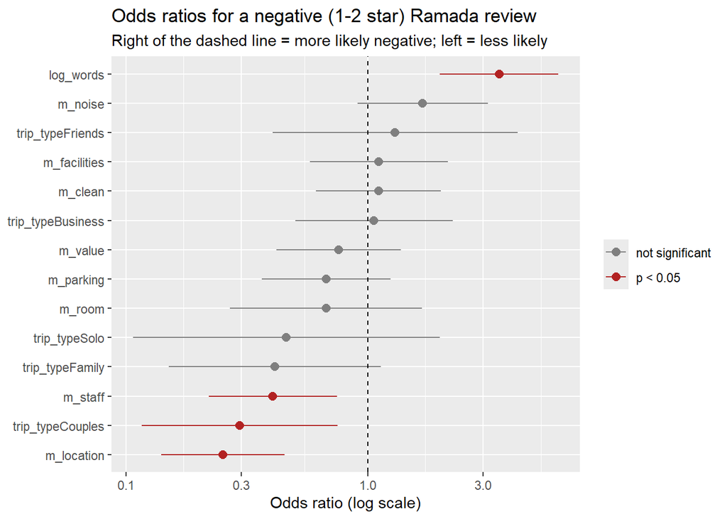

We classify a review as negative when the predicted probability is above 0.5 and compare with reality on the test reviews.

```
##               Actual
## Predicted      Negative Not negative
##   Negative           16            9
##   Not negative        9           35
```

```
## Accuracy
##    0.739
```

```
## Sensitivity Specificity
##       0.640       0.795
```

We now combine Ramada and competitor reviews and add a Ramada indicator, to see how much more likely a Ramada review is negative after allowing for topics and review length.

```
##              odds_ratio 2.5 % 97.5 %
## (Intercept)        0.00  0.00   0.00
## is_ramada          6.26  4.78   8.20
## m_room             1.20  0.97   1.50
## m_clean            1.12  0.97   1.29
## m_noise            0.91  0.78   1.06
## m_staff            0.55  0.47   0.63
## m_location         0.26  0.22   0.30
## m_parking          0.57  0.47   0.69
## m_value            1.20  1.03   1.39
## m_facilities       0.43  0.37   0.49
## log_words          4.49  3.95   5.09
```

**Interpretation:**

**Model for Ramada reviews only (280 training reviews)**

- About 37% of Ramada reviews are negative (1-2 stars).
- **Mentioning location** lowers the odds of a negative review by about **75%** (odds ratio 0.25, 95% CI 0.14 to 0.45, p < 0.001). Location is a source of satisfaction.
- **Mentioning staff or service** words lowers the odds by about **59%** (odds ratio 0.41, p = 0.004). This agrees with the keyword analysis: friendly, helpful staff appear in happy reviews.
- **Couples** have about 70% lower odds of a negative review than reviewers who did not state a trip type (odds ratio 0.30, p = 0.01). Business travellers are about the same as the reference group.
- **Longer reviews are much more likely to be negative** (odds ratio 3.5 per one-unit increase in log words, p < 0.001; doubling the length multiplies the odds by about 2.4). Unhappy guests write more.
- **Noise and sleep words** raise the odds of a negative review by about 69% (odds ratio 1.69), but this is **not significant at 5%** (p = 0.099) in this small sample, so it is only a hint. Room, cleanliness, parking, value and facilities words are not significant individually: a keyword can be mentioned positively or negatively (“clean room” or “dirty room”), and the sample is small.
- **Predictive performance:** on the 69 test reviews, accuracy is about **74%** (it catches 64% of the truly negative reviews and correctly clears 80% of the others). This is acceptable but not strong, so we use the model to *understand* what drives negative reviews, not to predict them.

**Combined model (Ramada plus competitors)**

- The Ramada indicator has an odds ratio of about **6.3** (95% CI 4.8 to 8.2). Even for reviews of the same length that mention the same topics, a Ramada review has roughly **six times the odds** of being negative compared with a competitor review. The problem is not limited to a single topic: the overall guest experience is worse.

#8. Summary: Ramada’s strengths and weaknesses

| rating | Ramada_mean | Comp_mean | p_value | difference | verdict |
| --- | --- | --- | --- | --- | --- |
| overall | 3.01 | 3.93 | 3.08e-36 | -0.92 | Ramada significantly LOWER |
| room | 3.19 | 4 | 2.65e-14 | -0.81 | Ramada significantly LOWER |
| value | 3.25 | 4.06 | 2.22e-15 | -0.81 | Ramada significantly LOWER |
| sleep | 3.42 | 4.1 | 5.32e-11 | -0.68 | Ramada significantly LOWER |
| cleanliness | 3.67 | 4.26 | 1.03e-10 | -0.59 | Ramada significantly LOWER |
| service | 3.59 | 4.17 | 1.13e-12 | -0.58 | Ramada significantly LOWER |
| location | 4.39 | 4.39 | 0.785 | 0 | No significant difference |

**Strengths (keep and promote)**

**Location** Rating 4.39, the same as competitors and ranked 28th of 71 in Hamilton. Mentioned in 61% of reviews; repeated phrases such as “central location”, “walk distance” and “right in the middle of town”; mentioning location cuts the odds of a negative review by about 75%.

**Responsiveness** Replies to about 86% of reviews vs 54% for competitors (and 86% of negative reviews vs 32%).

**Friendly, helpful staff (when it works)** “Staff be friendly and helpful” is repeated in 9 reviews at n = 5 (average rating 4.1); mentioning staff cuts the odds of a negative review by about 59%. The service rating (3.59) is still below competitors.

**Clean, comfortable rooms for happy guests** Repeated phrases “clean and tidy”, “room be clean and tidy” and “bed be comfortable”; the clean/staff/location topic has an average rating of 3.96 and only 12% negative reviews.

**Weaknesses (fix first)**

**Rooms and bathrooms** Room rating 3.19 vs 4.00 (p < 0.001). The topic *bed, bathroom, shower, door, smell, window, noise* covers 29% of reviews, with an average rating of 1.99 and 71% negative. Phrases: “step into the shower” (average rating 2.0), “bathroom be ridiculously small”, “hole in the wall”.

**Smells and cleanliness** Cleanliness 3.67 vs 4.26; at every n the strongest negative phrases are about musty, damp, stale and cigarette smells.

**Noise and sleep** Sleep rating 3.42 vs 4.10; the *Noise & sleep* aspect has the lowest rating (2.61) and the biggest gap (-1.2); phrases “on the main street” (2.6), “room be on the main street”, “very loud repetitive noise”.

**Value for money and extra charges** Value rating 3.25 vs 4.06 (p < 0.001) while the price is above most Hamilton competitors; phrases “extra cost” (6 reviews, average 2.3), “pay for park”, “to pay for wifi” and “don’t waste your money”.

**Parking and access** Mentioned in 42% of reviews vs 21% for competitors; the phrase grows from “car park” to “get from the car park to” (average about 2.3 to 2.7); the parking, arrival and reception topic has 28% negative reviews.

**Building layout** “Rabbit warren” (9 reviews at n = 2, average 2.4) and “bit of a maze” appear in the repeated phrases.

**Service consistency and problem handling** Service 3.59 vs 4.17; “the front desk” (average 2.4), “customer service”; strongest negative phrases include “useless and rude”; the booking and check-in topic has 36% negative reviews.

**More negative wording, and no improvement over time** Ramada has about 1.5 times the competitors’ share of negative n-grams at every n, and the share has been higher every year since 2014; ratings were 2.99 (up to 2019) vs 3.04 (2022 onward), p = 0.68.

# 9. Machine Learning Models and Price Prediction

##9.1 Planning the model

The manager wants an estimate of what the hotel should cost given its features. We train several models on hotels with a known price and see which predicts best on hotels it has not seen. Key decisions:

- **Target:** `price`. Because price is right-skewed, we model `log(price)` and convert predictions back to dollars with `exp()`.
- **Outliers:** a few ultra-luxury lodges (over $1,000 per night, for example a $4,014 lodge) behave very differently from a city hotel like Ramada, so we exclude hotels above $1,000 from training.
- **Variables excluded to avoid leakage:** `offer_pricemin`, `offer_pricemax` (they are almost the same as price) and `price_class` / `price_cat` (price missing and price class missing occur for exactly the same hotels, so it is derived from price).
- **Missing predictors:** replaced by the median plus a `no_rating` flag.
- **Fair testing:** 80% of hotels train the model and 20% are kept aside as a test set.

```
## Hotels with a price: 435
```

```
## Removed as extreme (> $1000): 9
```

```
## Hotels used for modelling: 426
```

```
## [1] 0
```

## 9.2 Train / test split

```
## Training hotels: 342  Test hotels: 84
```

## 9.3 Linear regression in detail

Linear regression is the most explainable model: it tells us how much each factor changes the price. Because the target is `log(price)`, a coefficient `b` means that a one-unit increase in the variable changes the price by about `exp(b) - 1` percent (for example `b = 0.28` gives about +32%).

Before fitting, we check multicollinearity: when predictors overlap strongly, coefficients become unstable. The VIF (variance inflation factor) measures this: values above about 5 suggest overlap and above 10 is serious.

```
##       rating_service          rating_room   rating_cleanliness
##                  7.0                  6.8                  6.2
##         rating_value               review       rating_overall
##                  6.0                  5.8                  5.4
##                photo         rating_sleep        amenity_count
##                  5.2                  4.8                  3.7
##      rating_location      amenity_parking         amenity_wifi
##                  3.5                  2.4                  2.0
##      amenity_kitchen amenity_breakfastinc                 room
##                  1.8                  1.8                  1.6
##             rank_pct            no_rating         amenity_pool
##                  1.6                  1.6                  1.4
##            longitude             star_num             latitude
##                  1.2                  1.2                  1.2
```

The rating scores overlap the most (VIF about 5 to 7). For an explainable model we therefore keep only a few representative variables: overall, room and value ratings, star class, size, photos, a few amenities, location and type.

```
##       star_num           room          photo rating_overall    rating_room
##            1.2            1.3            1.3            4.3            3.3
##   rating_value  amenity_count
##            3.1            1.1
```

```
##
## Call:
## lm(formula = lm_formula, data = train_x)
##
## Residuals:
##      Min       1Q   Median       3Q      Max
## -1.53849 -0.21164  0.01968  0.20512  1.08007
##
## Coefficients:
##                             Estimate Std. Error t value Pr(>|t|)
## (Intercept)                6.6253093  2.5552194   2.593 0.009957 **
## categoryBed and Breakfast -0.0829540  0.0645847  -1.284 0.199926
## categorySpecialty Lodging -0.0052170  0.0609690  -0.086 0.931863
## areaHamilton              -0.2044736  0.0976874  -2.093 0.037126 *
## areaWhitianga             -0.0878720  0.1479561  -0.594 0.552996
## areaCambridge             -0.0593933  0.1188826  -0.500 0.617704
## areaCoromandel            -0.2174278  0.1618886  -1.343 0.180204
## areaThames                -0.3415352  0.1566475  -2.180 0.029967 *
## areaTurangi               -0.1828032  0.1331228  -1.373 0.170657
## areaRaglan                 0.3932572  0.1602890   2.453 0.014685 *
## areaWaihi                 -0.0437752  0.1583314  -0.276 0.782359
## areaWhangamata             0.0020719  0.2042213   0.010 0.991912
## areaOther                 -0.0251212  0.0889470  -0.282 0.777798
## star_num                   0.2765536  0.0372261   7.429 1.01e-12 ***
## room                      -0.0005979  0.0012027  -0.497 0.619427
## photo                      0.0002396  0.0002209   1.085 0.278833
## rating_overall             0.0288512  0.0799806   0.361 0.718542
## rating_room                0.2424710  0.0672117   3.608 0.000359 ***
## rating_value              -0.0666694  0.0659470  -1.011 0.312805
## amenity_count              0.0339252  0.0106487   3.186 0.001586 **
## amenity_parking           -0.3209546  0.0828746  -3.873 0.000131 ***
## amenity_breakfastinc       0.2048907  0.0604285   3.391 0.000785 ***
## latitude                   0.0825698  0.0649787   1.271 0.204754
## ---
## Signif. codes:  0 '***' 0.001 '**' 0.01 '*' 0.05 '.' 0.1 ' ' 1
##
## Residual standard error: 0.3842 on 319 degrees of freedom
## Multiple R-squared:  0.4151, Adjusted R-squared:  0.3748
## F-statistic: 10.29 on 22 and 319 DF,  p-value: < 2.2e-16
```

| variable | coefficient | pct_change_in_price | p_value |
| --- | --- | --- | --- |
| areaRaglan | 0.393 | 48.2 | 0.0147 |
| star_num | 0.277 | 31.9 | 1.01e-12 |
| areaThames | -0.342 | -28.9 | 0.03 |
| amenity_parking | -0.321 | -27.5 | 0.000131 |
| rating_room | 0.242 | 27.4 | 0.000359 |
| amenity_breakfastinc | 0.205 | 22.7 | 0.000785 |
| areaHamilton | -0.204 | -18.5 | 0.0371 |
| amenity_count | 0.034 | 3.5 | 0.00159 |

**Checking the assumptions.** The four standard diagnostic plots show whether a linear model is reasonable: residuals should scatter randomly around zero (top left), follow the straight line in the Q-Q plot (top right), have a constant spread (bottom left) and no single point should dominate (bottom right).

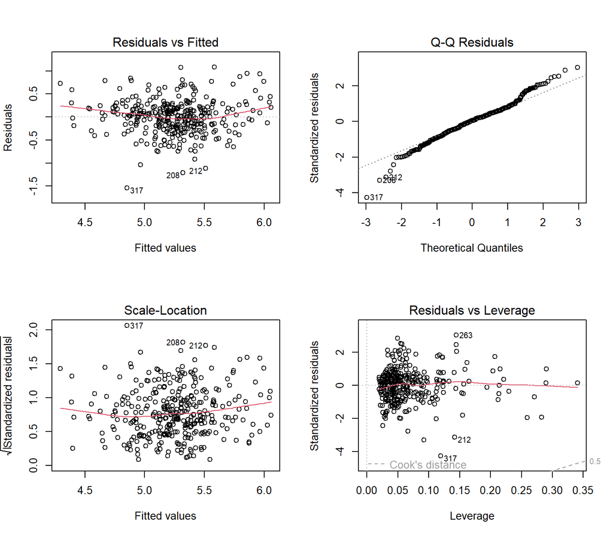

## 9.4 Training the models

We try models from simple to flexible, because no single model is always best:

**Baseline** Always predict the average price. Any useful model must beat this.

**Linear regression** Price changes in a straight line with each variable. Easy to explain.

**Lasso / ridge (glmnet)** Linear regression that shrinks unhelpful variables, which reduces over-fitting.

**Decision tree** Asks a series of yes/no questions to group similar hotels.

**K-nearest neighbour (KNN)** Predicts a hotel’s price as the average price of the *k* most similar hotels.

**Random forest** Averages hundreds of trees. Usually accurate, harder to explain.

We use **5-fold cross-validation repeated 3 times** (the training data is split into 5 parts; the model is trained on 4 parts and checked on the 5th, and this is repeated for every part and three different random splits). This tunes each model fairly and gives a more stable error estimate than a single split.

| alpha | lambda |
| --- | --- |
| 0.1 | 0.0365 |

| cp |
| --- |
| 0.0282 |

| k |
| --- |
| 13 |

| mtry |
| --- |
| 33 |

## 9.5 Comparing the models on the test set

The test hotels were never used for training, so errors on them show how the model would perform on a new hotel such as Ramada. We also show the cross-validated error from the training data (on the log scale, so it is a proportional error). The measures are:

- **RMSE** (root mean squared error): typical error size; punishes big mistakes.
- **MAE** (mean absolute error): average error in dollars.
- **R-squared:** share of the variation in price the model explains (0 = nothing, 1 = everything).

| Model | CV_RMSE_log | CV_R2 | Test_RMSE | Test_MAE | Test_R2 |
| --- | --- | --- | --- | --- | --- |
| Baseline (average price) |  |  | 69.7 | 55.9 | 0 |
| Linear regression | 0.404 | 0.321 | 67.5 | 49.5 | 0.209 |
| Lasso/Ridge (glmnet) | 0.401 | 0.32 | 66.2 | 49.2 | 0.214 |
| Decision tree | 0.429 | 0.226 | 74.9 | 52.7 | 0.053 |
| K-nearest neighbour | 0.428 | 0.238 | 62.8 | 45.8 | 0.199 |
| Random forest | 0.382 | 0.376 | 69.9 | 49.1 | 0.156 |

```
## Best model by cross-validation: Random forest
```

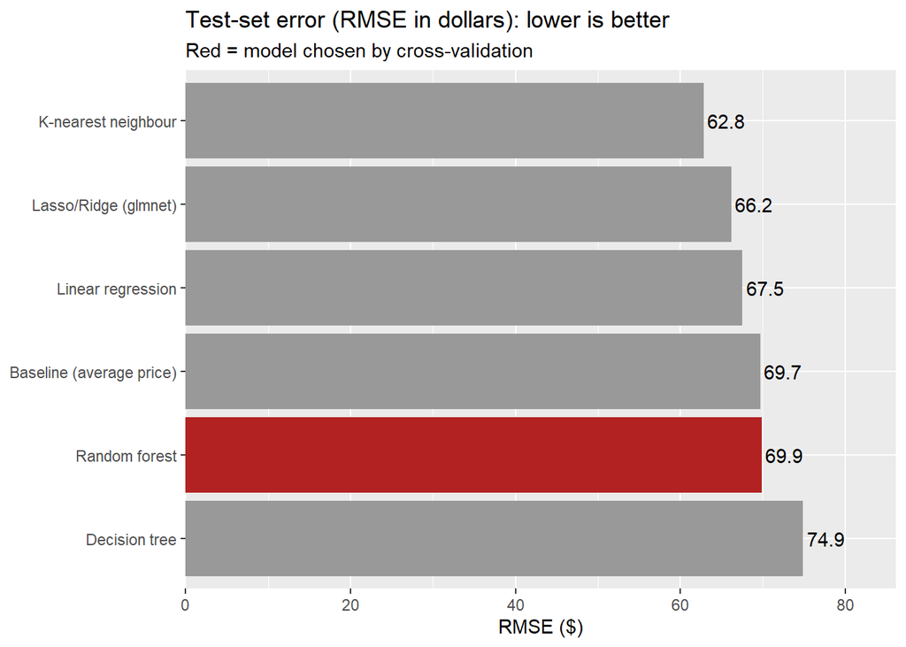

**Interpretation:**

The variables available explain only part of what hotels charge. Room quality, season, special events, brand and the exact room type are not in the data. The prediction should be used as a **guide, not an exact price**.

## 9.6 Checking the best model

We plot predicted against actual prices (points near the diagonal line are good predictions) and look at the errors.

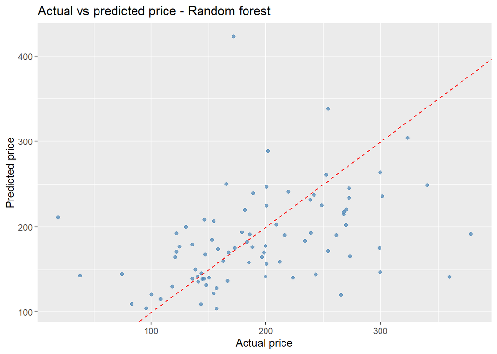

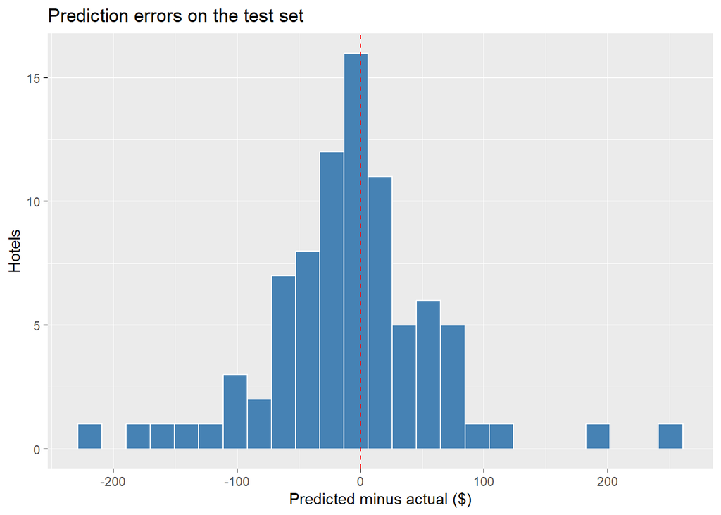

## 9.10 Looking inside the decision tree

A decision tree is easy to read: each box asks a yes/no question about a hotel, and the final boxes (leaves) give the average log price of the hotels that end up there. We convert each leaf to dollars so that we can see what kind of hotel each leaf represents.

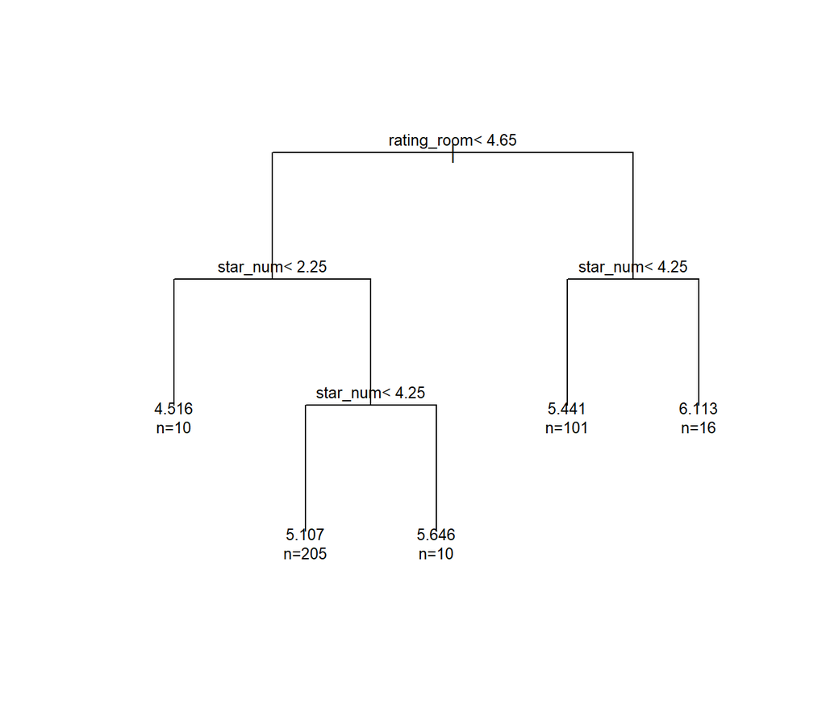

| hotels_in_leaf | typical_price |
| --- | --- |
| 10 | 91 |
| 205 | 165 |
| 10 | 283 |
| 101 | 231 |
| 16 | 452 |

```
## Decision tree estimate for Ramada: $ 165.16
```

**Interpretation:**

- The tree uses only **two variables: the room rating (first split at 4.65) and the star class**. This again shows that room quality and stars are what the market prices.
- There are five leaves with typical prices of about **$91** (very low-star hotels, 10 hotels), **$165** (205 hotels: room rating below 4.65 and 2.25 to 4.25 stars), **$283** (high-star hotels with room rating below 4.65, 10 hotels), **$231** (room rating 4.65 or more but under 4.25 stars, 101 hotels) and **$452** (room rating 4.65 or more and 4.25 or more stars, 16 hotels).
- **Ramada** (room rating 3.2, 3.5 stars) falls in the big middle leaf, with an estimate of about **$165**. To reach the $231 leaf, the room rating would need to rise above 4.65, which is a high bar and shows how much a really good room rating is worth.
- The tree is easy to read but coarse: it can only give five different prices, and it had the highest test error. It is best used for explanation, not for the final prediction.

## 9.11 Variables drive the price?

Variable importance from the random forest tells us which features the model relies on most. This helps the manager see what the market rewards.

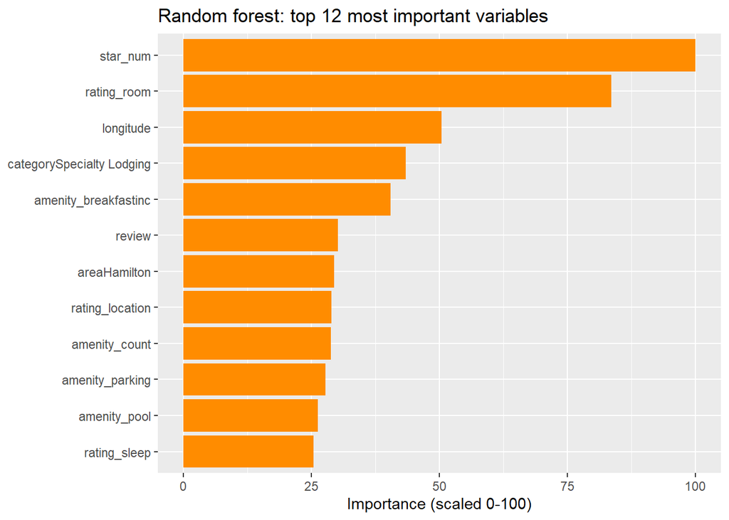

# 10. Predicting Ramada’s price

Now we apply the models to Ramada’s row in `hotel_pred`. It goes through the *same* preparation steps as the training data. We show every model’s prediction, the best model’s estimate, and a rough 80% range based on the typical error on the test set.

| Model | Predicted_price |
| --- | --- |
| Linear regression | 169 |
| Lasso/Ridge (glmnet) | 169 |
| Decision tree | 165 |
| K-nearest neighbour | 157 |
| Random forest | 168 |

| Current price | Predicted price | Approx. 80% range | Difference ($) | Difference (%) |
| --- | --- | --- | --- | --- |
| 184 | 168 | $97 to $292 | 15.7 | 9.3 |

## 10.1 What if Ramada’s guest ratings improved?

The model uses ratings as predictors. We can ask: *what would the model predict if Ramada’s scores matched the Hamilton competitor average?* This shows the price value of improving guest experience.

| Scenario | Predicted_price |
| --- | --- |
| Ramada as it is today | 168 |
| Ramada rated like the Hamilton average | 179 |

## 10.2 K-nearest neighbour: Ramada’s most similar hotels

KNN is the easiest model to explain to a manager: *“hotels like yours charge about this much”*. We measure how similar every hotel is to Ramada (using the standardised numeric variables) and list the 5 nearest hotels. First, the plot shows how the error changed as we tried different numbers of neighbours *k* (the best *k* is the lowest point).

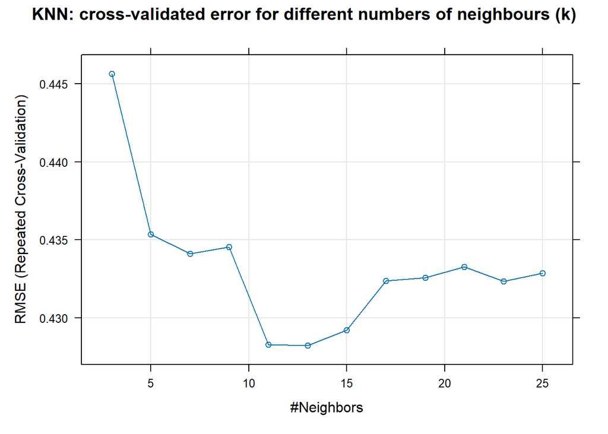

| name | locality | category | hotel_class | room | rating_overall | price | distance |
| --- | --- | --- | --- | --- | --- | --- | --- |
| Te Aroha Holiday Park - Campground & Hot Pools | Te Aroha | Specialty Lodging | 3 | 78 | 3.4 | 76.5 | 2.66 |
| Anglesea Motel & Conference Centre | Hamilton | Hotel | 4 | 48 | 3.5 | 116 | 3.16 |
| Aspen Manor Motel | Hamilton | Hotel | 4 | 31 | 3.3 | 138 | 3.21 |
| Tudor Motor Lodge | Hamilton | Hotel | 3 | 24 | 3.3 | 130 | 3.21 |
| Okoroire Hot Springs Hotel | Tirau | Bed and Breakfast | 3 | 20 | 3.5 | 245 | 3.31 |

```
## Average price of the 5 most similar hotels: $ 141
```

```
## KNN model estimate for Ramada: $ 157.27
```

# 11. Findings, Recommendations and Conclusion

## 11.1 Major findings

1. **Ramada is clearly behind its Hamilton competitors.** Its average review rating is **3.01 vs 3.93** (hotel-level scores 3.0 vs 3.76, ranked 62nd of 80). About **37% of Ramada reviews are 1-2 stars compared with 13%** for competitors.
2. **The gaps are statistically significant on six of seven aspects** (all p < 0.001): overall (-0.92), room (-0.81), value (-0.81), sleep (-0.68), cleanliness (-0.59) and service (-0.58). **Only location is equal** (4.39).
3. **Strengths:** location, a very high review response rate (86% vs 54%), and friendly, helpful staff and cleanliness in satisfied guests’ reviews.
4. **Weaknesses seen in the review text:** room and bathroom condition (bathroom, shower, door, bed, window), noise and poor sleep, smells and cleanliness, parking (mentioned twice as often as at competitors), and uneven handling of problems at reception.
5. **No improvement over time:** the average rating was 2.99 up to 2019 and 3.04 from 2022 onward (p = 0.68). Business travellers, a large group of reviewers, are among the least satisfied (about 2.7).
6. **Quality drives price, and Ramada’s quality score is low.** PCA shows that the six ratings are really one “overall quality” score (83% of the information); **75% of Hamilton competitors score better than Ramada**, while its location score is unusually strong. In the linear regression, each extra star adds about 32% to price and each point of room rating about 27%. Ramada’s room rating (3.2) is 0.6 below the Hamilton average.
7. **Ramada’s true peers are lower-rated motels and lodges.** Cluster analysis places Ramada in a group of 17 Hamilton properties with an average price of $136 and rating of 3.12, not with the high-rated group (price $206, rating 4.39). Ramada’s price is about **35% above its peers** although its ratings are the same as theirs, and its five most similar hotels average only about $141.
8. **Negative reviews:** even after allowing for topics and review length, a Ramada review has about **six times the odds of being 1-2 stars** compared with a competitor’s review. Within Ramada’s reviews, mentioning location or staff is linked to happy guests, while noise is the topic most linked to unhappy guests (a hint only, p = 0.099).
9. **Pricing:** Ramada’s $183.50 is **higher than about 63% of Hamilton hotels**.

[output not shown]

## 11.2 Recommendations

**1. Do not increase the price now.** Guests already rate value for money low (3.25 vs 4.06), the price is above most Hamilton competitors and about 35% above its true peer group, and all five models estimate a lower price than today’s. Consider revisiting the price once the room, noise and cleanliness ratings improve, and test any increase carefully (for example on a few room types) while monitoring the value rating.

**2. Fix the physical product first (highest priority).** Inspect and refurbish the worst rooms and bathrooms: shower and bathroom doors that do not close properly, tiny or tired bathrooms, mattresses and beds, worn carpet, smells and windows.

**3. Improve noise and sleep quality.** This is the largest aspect gap. Options are better window sealing or double glazing, servicing noisy air-conditioning units, door closers, offering quieter rooms away from the street, and providing earplugs.

**4. Raise cleanliness and air quality standards.** Add housekeeping audits and deep-cleaning schedules, address smells and ventilation, and enforce the non-smoking policy.

**5. Make parking clear and fair.** Parking is mentioned in 42% of reviews (21% at competitors) and “extra cost” appears in complaints. In `hotel_pred`, Ramada has no free-parking flag. State parking availability and cost clearly at booking, consider a parking package, and keep the Tripadvisor listing up to date.

**6. Make service consistent.** Train front-desk staff, empower the duty manager to solve problems on the spot, and make replies to reviews action-oriented (what has been fixed), keeping the strong reply rate.

**7. Target business travellers.** Provide a good work desk, reliable Wi-Fi, quiet rooms and a fast check-in and check-out, since this group rates the hotel lowest.

**8. Promote the strengths.** Market the central location and friendly staff, and invite satisfied guests to leave reviews so that the share of 4-5 star reviews rises.

**9. Track progress.** Suggested targets are an overall rating at the Hamilton average (about 3.8), room, sleep and value ratings within 0.3 points of competitors, and 1-2 star reviews below 20%. Repeat this analysis every 6 to 12 months.

# 12. Conclusion

Ramada has an excellent location and a responsive management team, but guests rate its rooms, sleep quality, cleanliness and value significantly below Hamilton competitors, and there has been no improvement over time. The price model puts the hotel’s current price above its central estimate (though within the uncertainty range), so it does not support an increase. The best path is therefore to improve the guest experience first and revisit the price later, because better room quality, quieter sleep and cleaner rooms are exactly the drivers that the market rewards.